# Google Trends Analysis with Data Visualization for 3 Different Datas from Turkey

Muhammed Ikbal Baykal - IE360 - Fall 2020

## 1) Yearly Mobile Phone Subcribers Data of Turkey over 2004-2010

Dataset shows the number of mobile phone subscribers annually from 2004 to 2010. There are no values after 2010 in the dataset. Because as a result of the research on Google Trends, it was observed that the term “kontor”, which means credits, was deleted from daily life. The trend between the increase in the search for the word “kontor” used in those years and the increase in the number of mobile phone subscribers was examined. Although the dataset is not large enough, it is possible to catch the trend between each other.

Here is the line chart of the dataset:

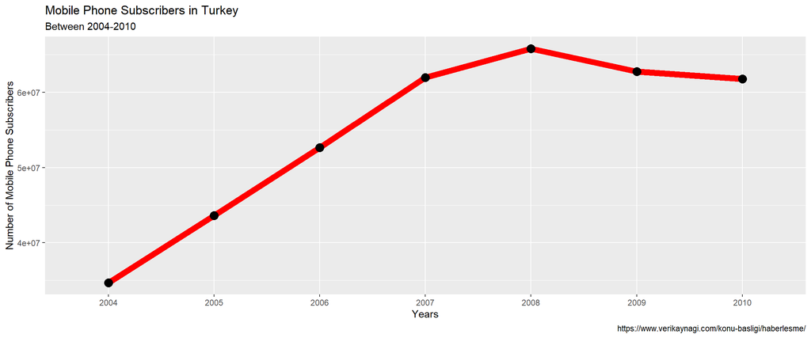

```r
setwd("C:/Users/90533/Desktop")

library(ggplot2)
library(knitr)
library(markdown)

data<-read.delim("Yeni Metin Belgesi.txt")
ggplot(data, aes(x=factor(Dates), y=Mobile.Phone.Subscribers, group=1)) + geom_line(color="red", size=3, linetype="solid") +
  geom_point(shape=21, fill="black", size=4)  + xlab("Years") + ylab("Number of Mobile Phone Subscribers") +
  labs(title="Mobile Phone Subscribers in Turkey", subtitle="Between 2004-2010", caption="https://www.verikaynagi.com/konu-basligi/haberlesme/")
```

The chart shows a linear increase in cell phone subscribers followed by a stability. It seems that the use of mobile phones became widespread throughout the country and has reached its peak.

Here is the line chart of Google Trends dataset:

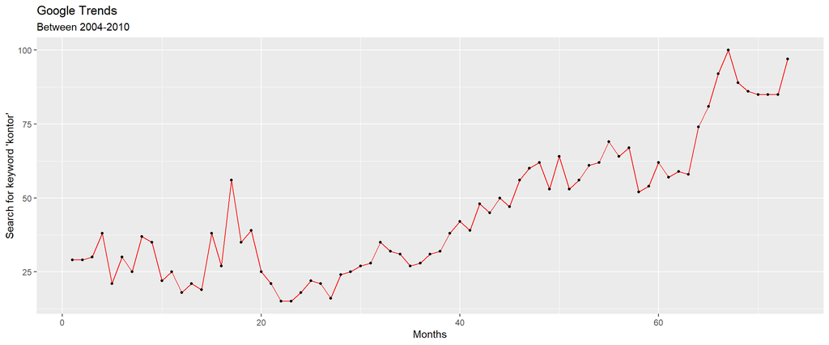

```r
setwd("C:/Users/90533/Desktop")

library(ggplot2)
library(knitr)
library(markdown)

trend<-read.delim("trend1.txt")
ggplot(trend, aes(x=Months, y=Trend)) + geom_line(color="red", size=0.5, linetype="solid") +
  geom_point(shape=21, fill="black", size=1)  + xlab("Months") + ylab("Search for keyword 'kontor'") +
  labs(title="Google Trends", subtitle="Between 2004-2010")
```

Since Google Trends datas are monthly datas, they have more values. For this reason, fluctuations are seen on the chart. There is a linear increase throughout the chart, except for the initial decrease. When these two graphs are compared, it is possible to say that:

-As people started using mobile phones, they had to load credits on the phone.

-For this reason, they searched how to add credits to the phone from the internet.

It can be concluded that there is a positive correlation between this double action.

Here is the histogram of the dataset:

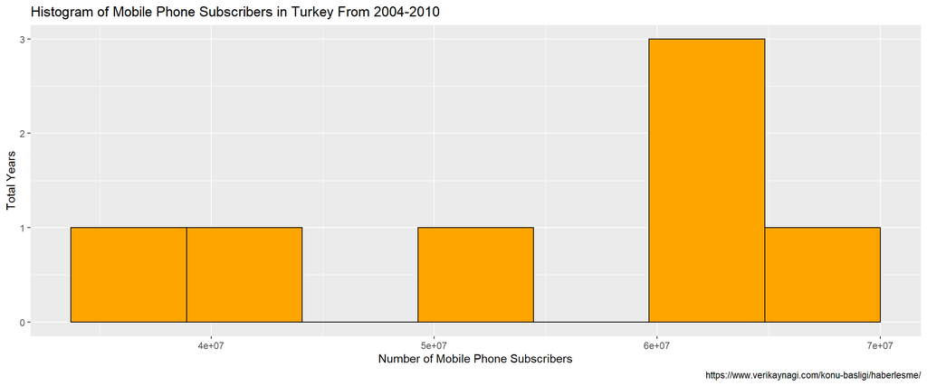

```r
setwd("C:/Users/90533/Desktop")

library(ggplot2)
library(knitr)
library(markdown)

ggplot(data, aes(Mobile.Phone.Subscribers)) + geom_histogram(bins = 7, color = "black", fill="orange") +
  labs(title = "Histogram of Mobile Phone Subscribers in Turkey From 2004-2010", x = "Number of Mobile Phone Subscribers", y = "Total Years",
       caption = "https://www.verikaynagi.com/konu-basligi/haberlesme/")
```

Here is the histogram of Google Trends’ dataset:

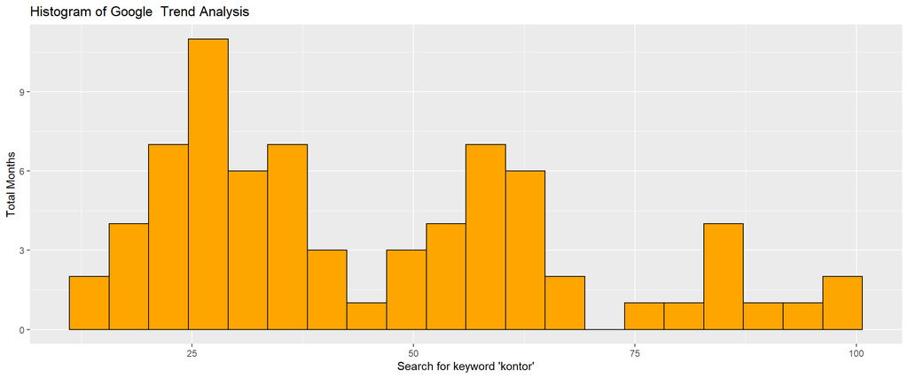

```r
setwd("C:/Users/90533/Desktop")

library(ggplot2)
library(knitr)
library(markdown)

ggplot(trend, aes(Trend)) + geom_histogram(bins = 20, color = "black", fill="orange") +
  labs(title = "Histogram of Google  Trend Analysis", x = "Search for keyword 'kontor'", y = "Total Months")
```

Here is the boxplot of the dataset:

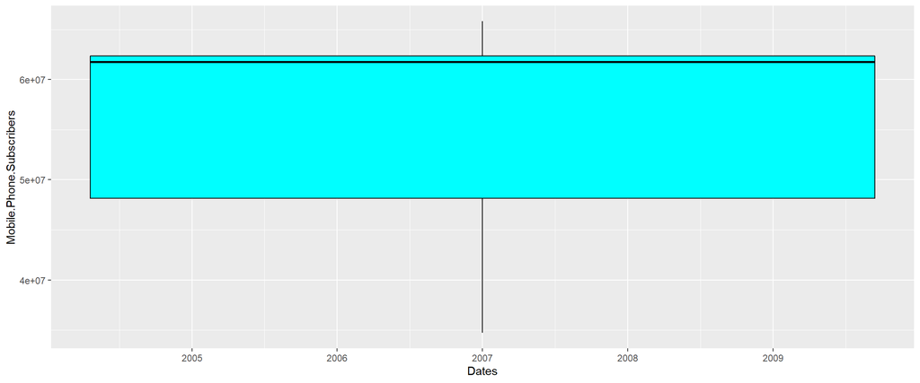

```r
setwd("C:/Users/90533/Desktop")

library(ggplot2)
library(knitr)
library(markdown)

ggplot(data, aes(x=Dates, y=Mobile.Phone.Subscribers, group=1)) + geom_boxplot(outlier.colour="black", outlier.shape=16,
             outlier.size=2, color = "black" , fill = "cyan")
```

Here is the boxplot of Google Trends’ dataset:

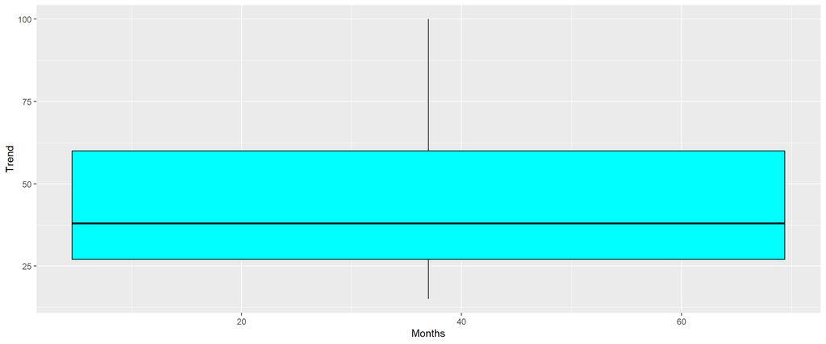

```r
setwd("C:/Users/90533/Desktop")

library(ggplot2)
library(knitr)
library(markdown)

ggplot(trend, aes(x=Months, y=Trend)) + geom_boxplot(outlier.colour="black", outlier.shape=16,
                                                                               outlier.size=2, color = "black" , fill = "cyan")
```

Boxplots do not have the necessary shape to read the graphics on themselves. Correct boxplots could not be reached due to an error in the code.

## 2) Monthly Unemployment Rate Data of Turkey over 2005-2020

Here is the line chart of the dataset:

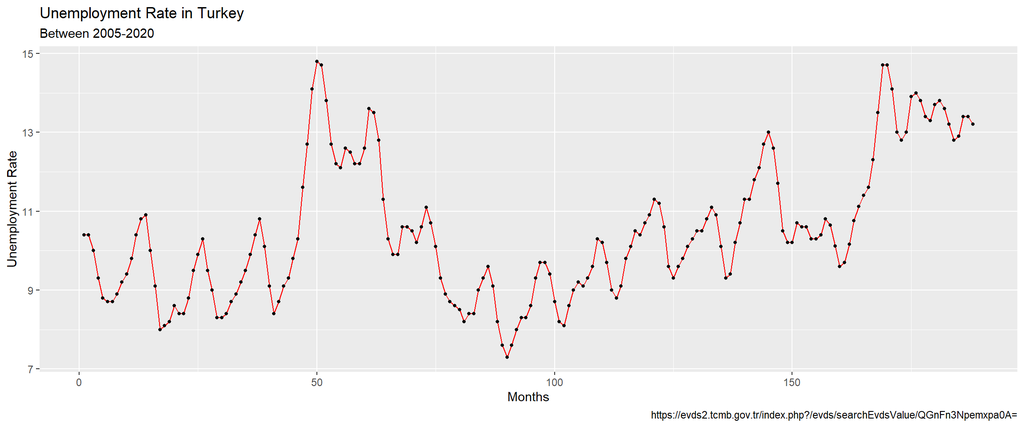

```r
setwd("C:/Users/90533/Desktop")

library(ggplot2)
library(knitr)
library(markdown)

data2<-read.delim("Yeni Metin Belgesi (2).txt")
ggplot(data2, aes(x=data2$Months, y=data2$Rate)) + geom_line(color="red", size=0.5, linetype="solid") +
  geom_point(shape=21, fill="black", size=1)  + xlab("Months") + ylab("Unemployment Rate") +
  labs(title="Unemployment Rate in Turkey", subtitle="Between 2005-2020", caption="https://evds2.tcmb.gov.tr/index.php?/evds/searchEvdsValue/QGnFn3Npemxpa0A=")
```

Here is the line chart of Google Trends dataset:

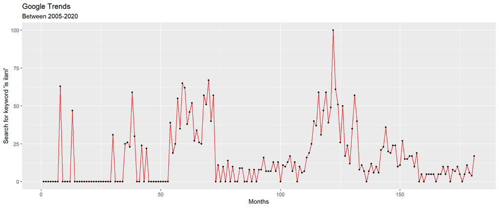

```r
setwd("C:/Users/90533/Desktop")

library(ggplot2)
library(knitr)
library(markdown)

trend2<-read.delim("trend2.txt")
ggplot(trend2, aes(x=Months, y=Trend)) + geom_line(color="red", size=0.5, linetype="solid") +
  geom_point(shape=21, fill="black", size=1)  + xlab("Months") + ylab("Search for keyword 'is ilani'") +
  labs(title="Google Trends", subtitle="Between 2005-2020")
```

-When the unemployment rate increases and the number of unemployed people increases accordingly, people search for the “is ilani” keyword to find jobs on the internet.

Here is the histogram of the dataset:

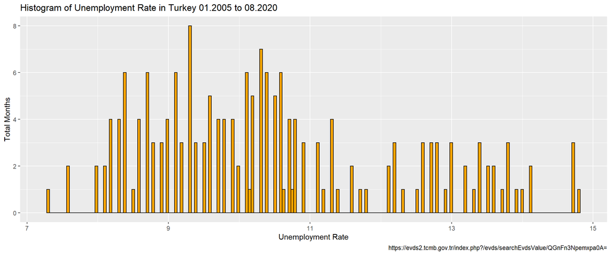

```r
setwd("C:/Users/90533/Desktop")

library(ggplot2)
library(knitr)
library(markdown)

ggplot(data2, aes(data2$Rate)) + geom_histogram(bins = 188, color = "black", fill="orange") +
  labs(title = "Histogram of Unemployment Rate in Turkey 01.2005 to 08.2020", x = "Unemployment Rate", y = "Total Months",
       caption = "https://evds2.tcmb.gov.tr/index.php?/evds/searchEvdsValue/QGnFn3Npemxpa0A=")
```

Here is the histogram of Google Trends’ dataset:

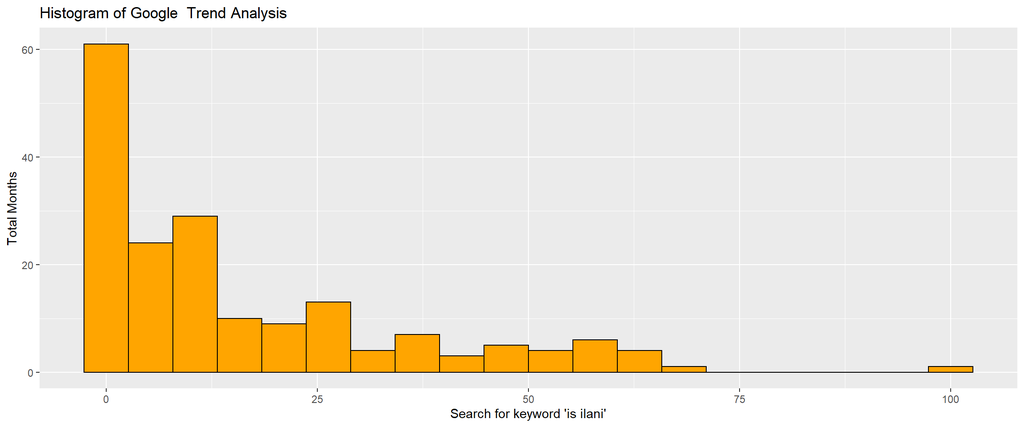

```r
setwd("C:/Users/90533/Desktop")

library(ggplot2)
library(knitr)
library(markdown)

ggplot(trend2, aes(Trend)) + geom_histogram(bins = 20, color = "black", fill="orange") +
  labs(title = "Histogram of Google  Trend Analysis", x = "Search for keyword 'is ilani'", y = "Total Months")
```

Here is the boxplot of the dataset:

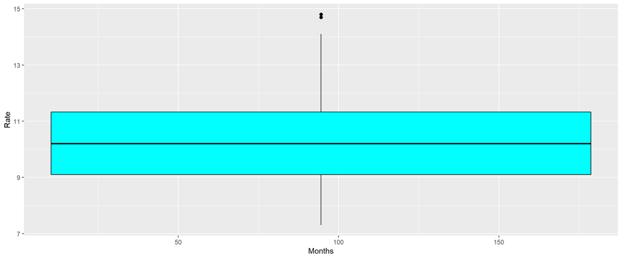

```r
setwd("C:/Users/90533/Desktop")

library(ggplot2)
library(knitr)
library(markdown)

ggplot(data2, aes(x=Months, y=Rate, group=1)) + geom_boxplot(outlier.colour="black", outlier.shape=16,
                                                                               outlier.size=2, color = "black" , fill = "cyan")
```

Here is the boxplot of Google Trends’ dataset:

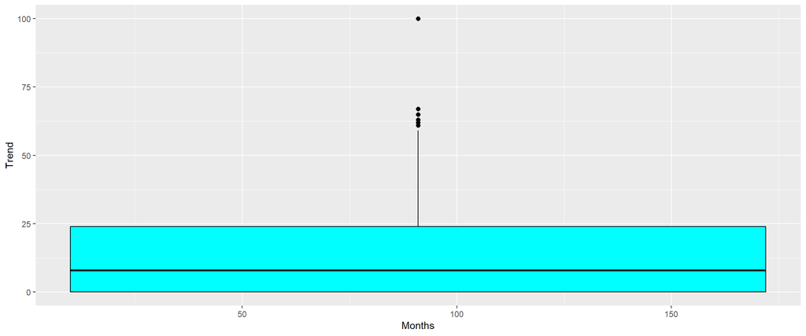

```r
setwd("C:/Users/90533/Desktop")

library(ggplot2)
library(knitr)
library(markdown)

ggplot(trend2, aes(x=Months, y=Trend)) + geom_boxplot(outlier.colour="black", outlier.shape=16,
                                                     outlier.size=2, color = "black" , fill = "cyan")
```

Boxplots do not have the necessary shape to read the graphics on themselves. Correct boxplots could not be reached due to an error in the code.

## 3) Monthly Exchange Rate Data of USD/TL over 2010-2020

Dataset shows monthly exchange rate of USD/TL from 01.2010 to 01.2020. The dataset was compared to “dolar” keyword searches on Google Trends. Datasets seems very suitable to catch the trend between them. The movements of the datasets on the graphs are similar to each other.

Here is the line chart of the dataset:

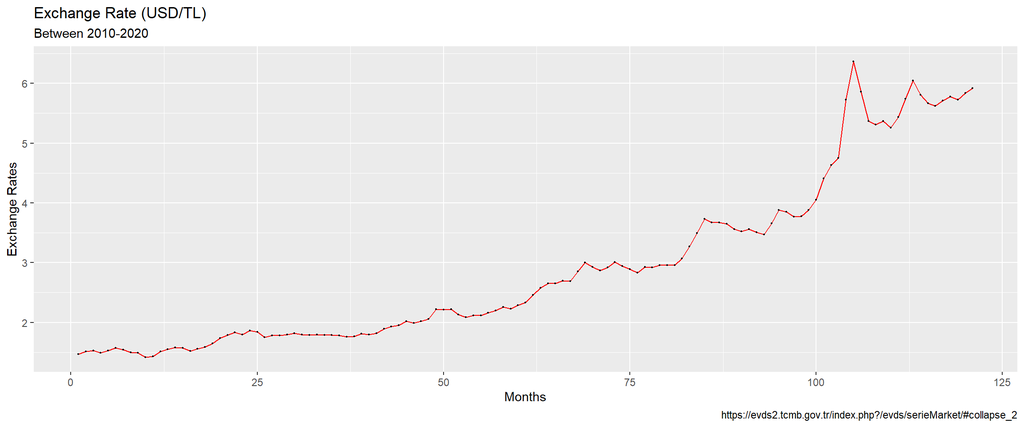

```r
setwd("C:/Users/90533/Desktop")

library(ggplot2)
library(knitr)
library(markdown)

data3<-read.delim("Yeni Metin Belgesi (3).txt")
ggplot(data3, aes(x=Months, y=Rate)) + geom_line(color="red", size=0.5, linetype="solid") +
  geom_point(shape=21, fill="black", size=0.3)  + xlab("Months") + ylab("Exchange Rates") +
  labs(title="Exchange Rate (USD/TL)", subtitle="Between 2010-2020", caption="https://evds2.tcmb.gov.tr/index.php?/evds/serieMarket/#collapse_2")
```

Here is the line chart of Google Trends dataset:

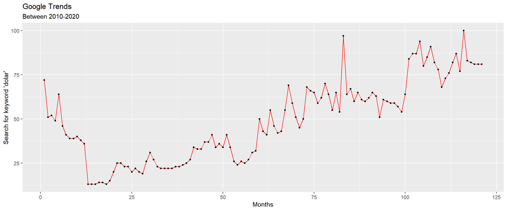

```r
setwd("C:/Users/90533/Desktop")

library(ggplot2)
library(knitr)
library(markdown)

trend3<-read.delim("trend3.txt")
ggplot(trend3, aes(x=Months, y=Trend)) + geom_line(color="red", size=0.5, linetype="solid") +
  geom_point(shape=21, fill="black", size=1)  + xlab("Months") + ylab("Search for keyword 'dolar'") +
  labs(title="Google Trends", subtitle="Between 2010-2020")
```

The first graph shows an exponential increase following a linear increase in exchange rates. In the second graph, it is observed that there are reactions to this increase except the initial decrease. Especially in the sudden increase in exchange rates in 2018, the increase in searches can be seen clearly. It is possible to observe that searches for the keyword “dolar” increase suddenly with every sudden increase. It is possible to say that:

-When the dollar goes up, people care about it.

-People who care about this are also looking for the “dolar” keyword on the internet because they are wondering what is going on.

-As a result, when the dollar goes up, the number of searches for the “dolar” keyword also increases.

It can be concluded that there is a positive correlation between this double action.

Here is the histogram of the dataset:

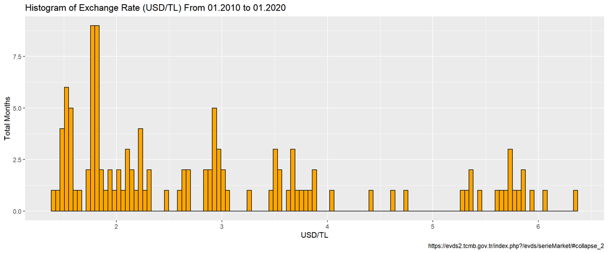

```r
setwd("C:/Users/90533/Desktop")

library(ggplot2)
library(knitr)
library(markdown)

ggplot(data3, aes(Rate)) + geom_histogram(bins = 121, color = "black", fill="orange") +
  labs(title = "Histogram of Exchange Rate (USD/TL) From 01.2010 to 01.2020", x = "USD/TL", y = "Total Months",
       caption = "https://evds2.tcmb.gov.tr/index.php?/evds/serieMarket/#collapse_2")
```

Here is the histogram of Google Trends’ dataset:

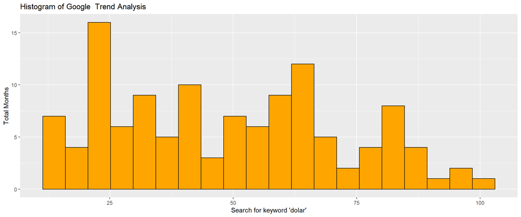

```r
setwd("C:/Users/90533/Desktop")

library(ggplot2)
library(knitr)
library(markdown)

ggplot(trend3, aes(Trend)) + geom_histogram(bins = 20, color = "black", fill="orange") +
  labs(title = "Histogram of Google  Trend Analysis", x = "Search for keyword 'dolar'", y = "Total Months")
```

Here is the boxplot of the dataset:

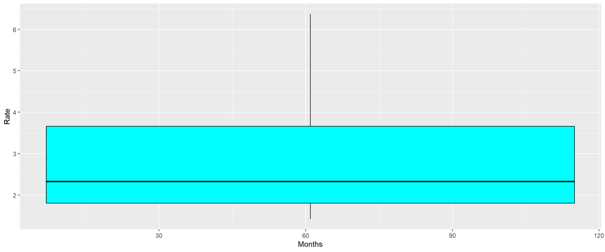

```r
setwd("C:/Users/90533/Desktop")

library(ggplot2)
library(knitr)
library(markdown)

ggplot(data3, aes(x=Months, y=Rate, group=1)) + geom_boxplot(outlier.colour="black", outlier.shape=16,
                                                             outlier.size=2, color = "black" , fill = "cyan")
```

Here is the boxplot of Google Trends’ dataset:

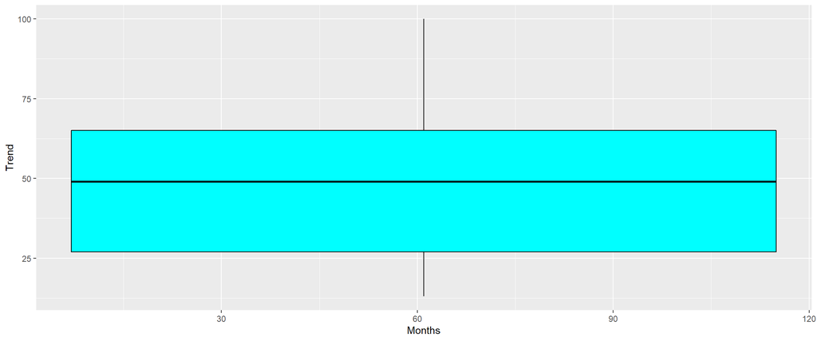

```r
setwd("C:/Users/90533/Desktop")

library(ggplot2)
library(knitr)
library(markdown)

ggplot(trend3, aes(x=Months, y=Trend)) + geom_boxplot(outlier.colour="black", outlier.shape=16,
                                                      outlier.size=2, color = "black" , fill = "cyan")
```

Boxplots do not have the necessary shape to read the graphics on themselves. Correct boxplots could not be reached due to an error in the code.